# Exploratory Data Analysis

# Exploratory Data Analysis

## Reading The Data

Load required libraries. Throughout this notebook, we’ll be using `tidyverse` (installed with `install.packages("tidyverse")`).

```r
library(tidyverse)
library(haven)
```

Read the data from the data folder, separated by baseline features and questionnaires.

```r
features <- read_dta("../data/baseline_features.dta")
questions_w1 <- read_dta("../data/questions_cisr_wave1.dta")
questions_w2 <- read_dta("../data/questions_cisr_wave2.dta")
dim(features)
```

```
[1] 15105  2288
```

```r
dim(questions_w1)
```

```
[1] 15105   176
```

```r
dim(questions_w2)
```

```
[1] 14014    64
```

### Outcome Variables (Questionnaires)

Let’s explore our the outcome variables. First we take a brief look at their format and distribution. Note that indices 1 equate to “NO”s while indices 2 correspond to “YES” answers.

```r
table(questions_w1$cisah6)
```

```
   0    1
3722 1180
```

```r
table(questions_w1$cisah8)
```

```
   0    1    2
2827  470   41
```

```r
table(questions_w1$cisah9a)
```

```
  0   1   2
345 101  23
```

```r
table(questions_w2$CISBH6)
```

```
   0    1
3300 1079
```

```r
table(questions_w2$CISBH8)
```

```
   0    1    2
2419  401   20
```

```r
table(questions_w2$CISBH9A)
```

```
  0   1   2
313  78  13
```

Now let’s explain each. For that, we must understand the questionnaire flow.

Every participant answered question G1. Of those, only the ones who responded positively followed to question G4. Analagously, everyone answered G2, but only the ones who responded negatively were prompted G5.

```r
g1 <- table(questions_w2$CISBG1)
g2 <- table(questions_w2$CISBG2)
g4 <- table(questions_w2$CISBG4)
g5 <- table(questions_w2$CISBG5)

cat(g1[2], "felt sad in last 30 days\n") # index 2 for YES
```

```
5531 felt sad in last 30 days
```

```r
cat(g4[2], "felt sad in last 7 days\n") # index 2 for YES
```

```
4124 felt sad in last 7 days
```

```r
cat(g2[1], "couldn't enjoy what they'd used to in last 30 days\n") # index 1 for NO
```

```
1815 couldn't enjoy what they'd used to in last 30 days
```

```r
cat(g5[1], "couldn't enjoy what they'd used to in last 7 days\n") # index 1 for NO
```

```
1374 couldn't enjoy what they'd used to in last 7 days
```

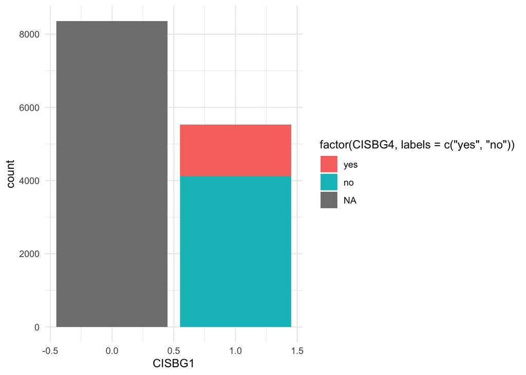

```r
ggplot(data = questions_w2, aes(x = CISBG1, fill = factor(CISBG4, labels = c("yes", "no")))) +
  geom_bar(stat = "count") +
  theme_minimal()
```

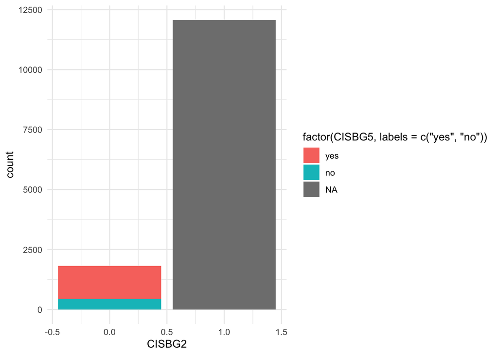

```r
ggplot(data = questions_w2, aes(x = CISBG2, fill = factor(CISBG5, labels = c("yes", "no")))) +
  geom_bar(stat = "count") +
  theme_minimal()
```

#### CIS-R H6 (hopelessness)

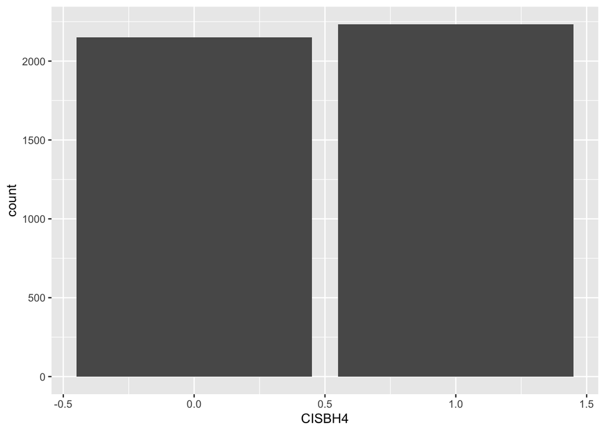

```r
# Question H4
ggplot(data = questions_w2) +
  geom_bar(mapping = aes(x = CISBH4))
```

```r
h4 <- table(questions_w2$CISBH4)
cat(h4[2], "felt guilty in last 7 days") # index 2 for YES
```

```
2234 felt guilty in last 7 days
```

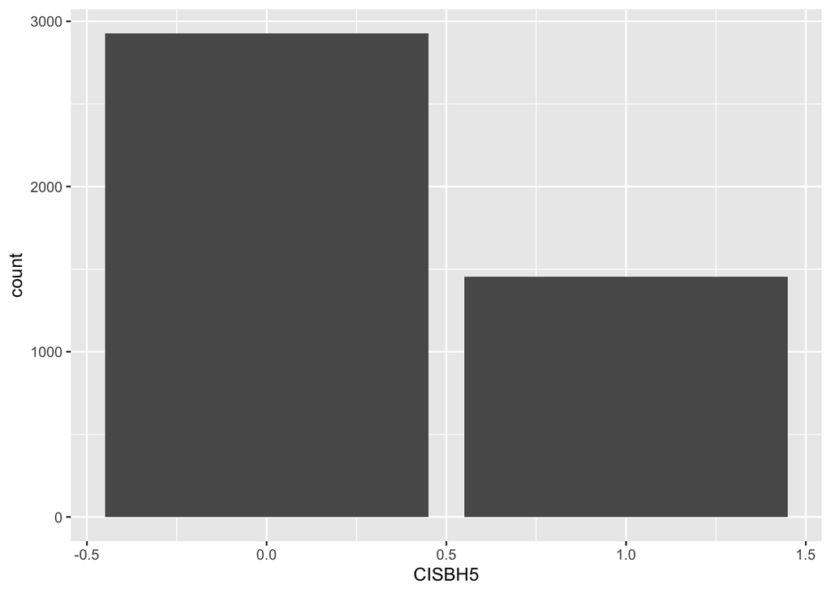

```r
# Question H5
ggplot(data = questions_w2) +
  geom_bar(mapping = aes(x = CISBH5))
```

```r
h5 <- table(questions_w2$CISBH5)
cat(h5[2], "felt not as good as others in last 7 days") # index 2 for YES
```

```
1454 felt not as good as others in last 7 days
```

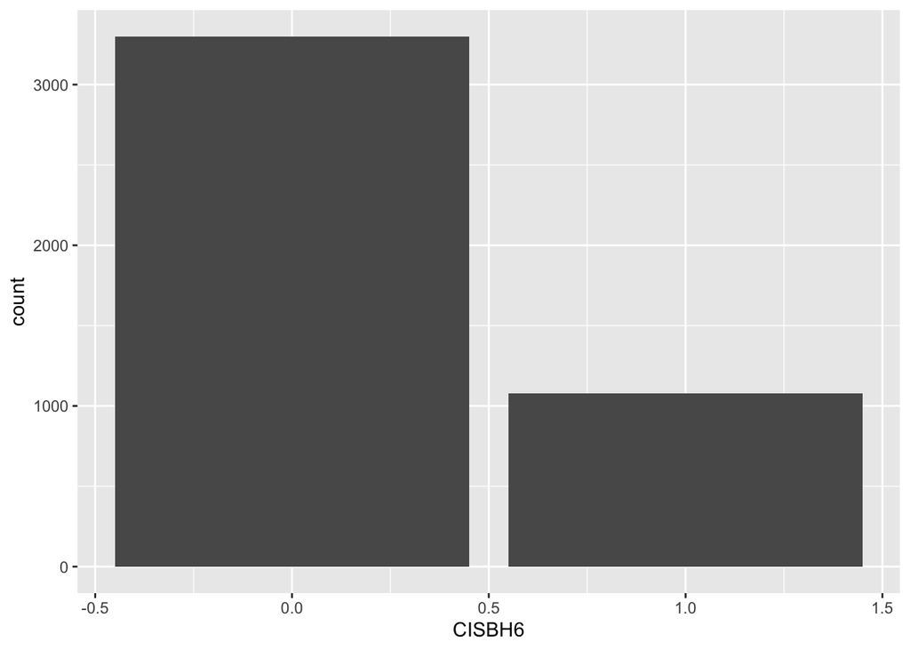

```r
# Question H6
ggplot(data = questions_w2) +
  geom_bar(mapping = aes(x = CISBH6))
```

```r
h6 <- table(questions_w2$CISBH6)
cat(h6[2], "felt hopeless in last 7 days") # index 2 for YES
```

```
1079 felt hopeless in last 7 days
```

#### CIS-R H8 (*taedium vitae*)

The participants who answered YES to H4, H5 or H6 were asked **H8 (our second outcome variable)**.

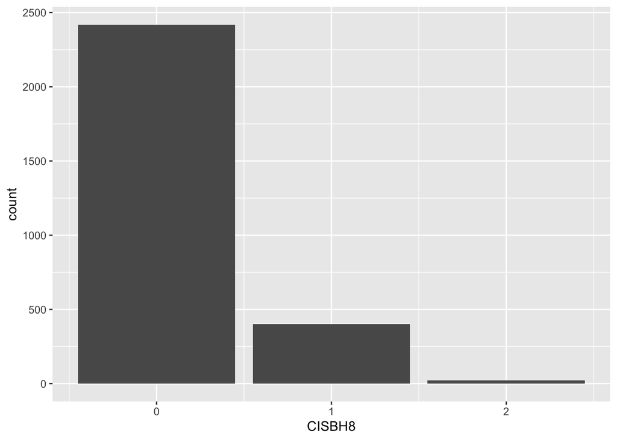

```r
# People that answered H4=YES or H5=YES or H6=YES answered H8
ggplot(data = questions_w2) +
  geom_bar(mapping = aes(x = CISBH8))
```

```r
h8 <- table(questions_w2$CISBH8)
cat(sum(h8[2:3]), "felt life was not worth living") # indices 2 & 3 for YES & YES*
```

```
421 felt life was not worth living
```

#### CIS-R H9 (suicide ideation)

Finally, only the participants who answered YES (in the last 7 days) were prompted to answer **H9, our last outcome variable**.

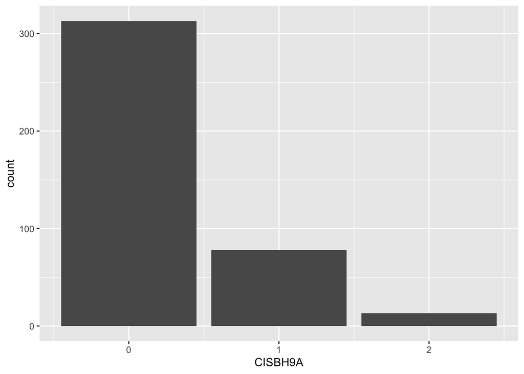

```r
# People that answered H8=YES (only in last 7 days) answered H9
ggplot(data = questions_w2) +
  geom_bar(mapping = aes(x = CISBH9A))
```

```r
h9 <- table(questions_w2$CISBH9A)
cat(sum(h9[2:3]), "thought about commiting suicide") # indices 2 & 3 for YES & YES*
```

```
91 thought about commiting suicide
```